# Mouse Allergen and Asthma Cohort Study (MAACS)

“Are overweight individuals, as measured by body mass index (BMI), more susceptible than normal weight individuals to the harmful effects of PM2.5 on asthma symptoms?”

NocturnalSymp, is the number of days in the past 2 weeks where the child experienced asthma symptoms (e.g. coughing, wheezing) while sleeping.

````r
```r
str(maacs)
````

‘data.frame’: 517 obs. of 4 variables: $ logpm25 : num 1.248 1.122 1.93 1.368 0.775 … $ logno2_new : num 1.184 1.552 1.432 1.774 0.765 … $ bmicat : chr weight weight … $ NocturnalSympt: int 1 0 0 2 0 0 0 0 0 3 …

````
```r
```r
g <- ggplot(maacs, aes(logpm25, NocturnalSympt))
summary(g)
````

data: logpm25, logno2_new, bmicat, NocturnalSympt [517x4] mapping: x = ~logpm25, y = ~NocturnalSympt faceting: <ggproto object: Class FacetNull, Facet, gg> compute_layout: function draw_back: function draw_front: function draw_labels: function draw_panels: function finish_data: function init_scales: function map_data: function params: list setup_data: function setup_params: function shrink: TRUE train_scales: function vars: function super: <ggproto object: Class FacetNull, Facet, gg> ```

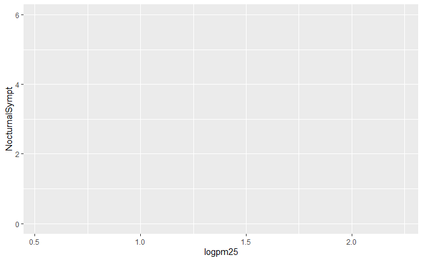

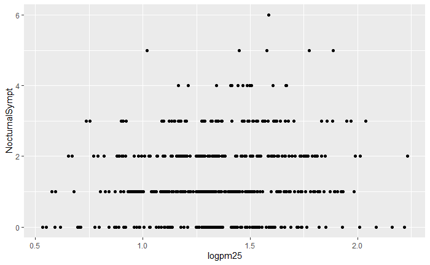

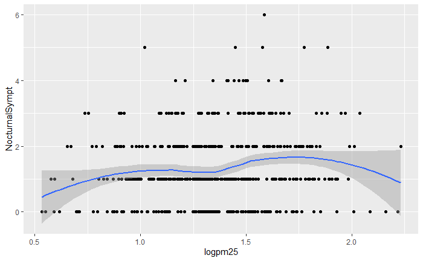

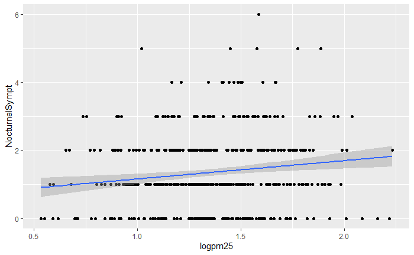

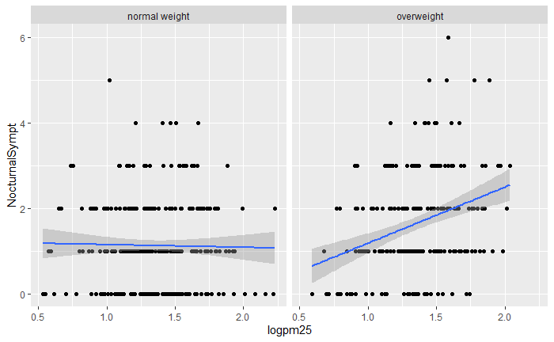

Panel izquierdo, no parece que siga una tendencia lineal, en el panel derecho, tendencia hacia arriba, de forma generalizada en todos los puntos, por lo tanto las personas con sobrepeso tienden a mostrar más síntomas de asmas conforme la concentración de las partículas aumentar pm25

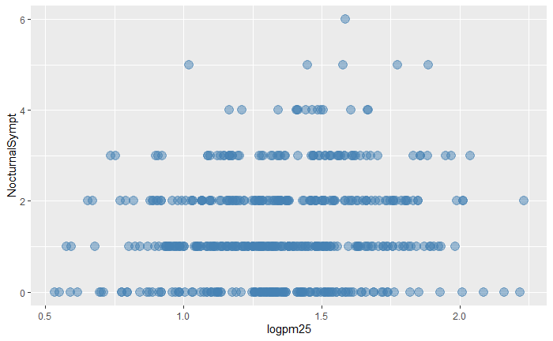

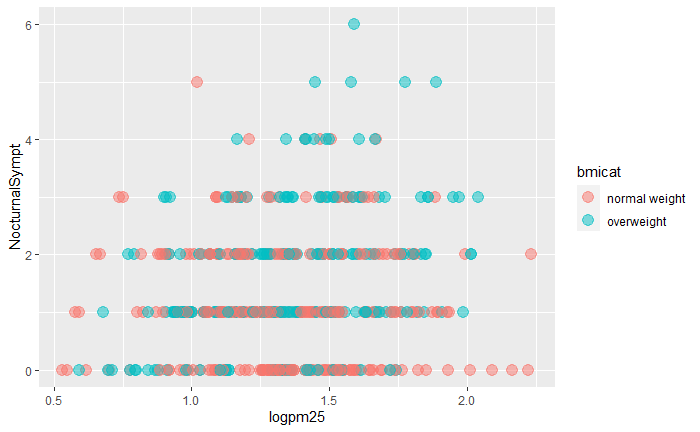

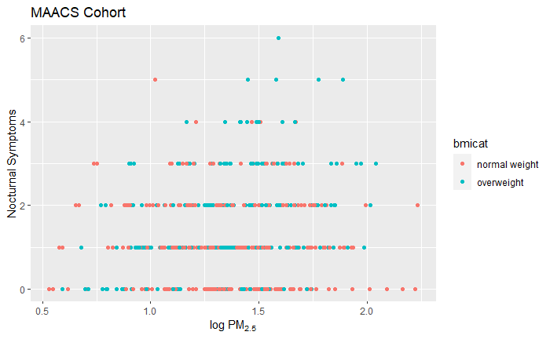

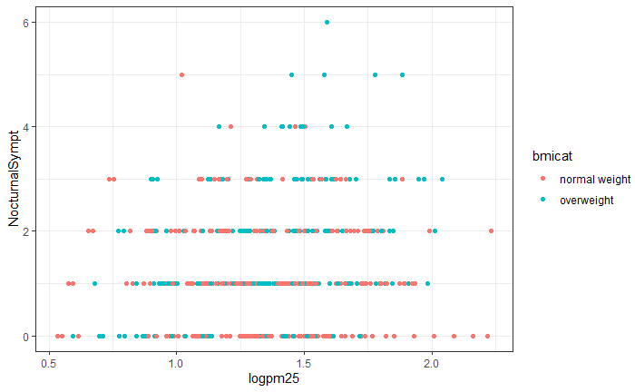

Extra y-limits

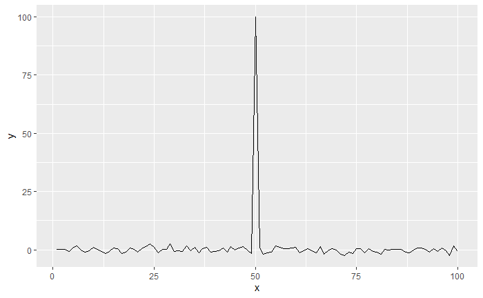

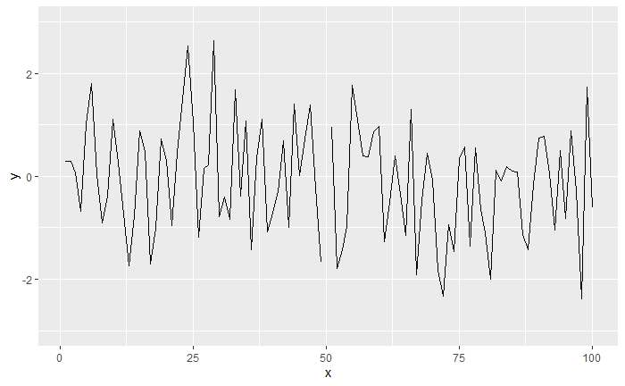

What this does is subset the data so that only observations between -3 and 3 are included, then plot the data.

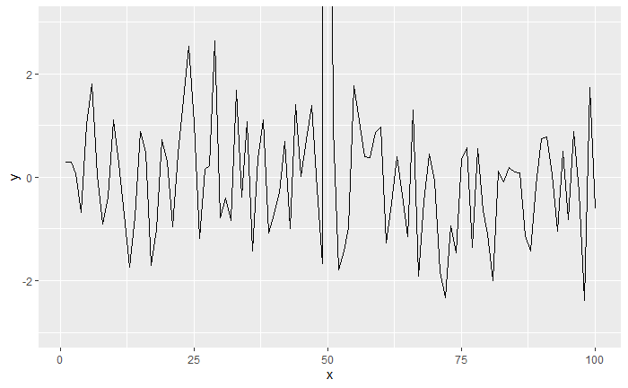

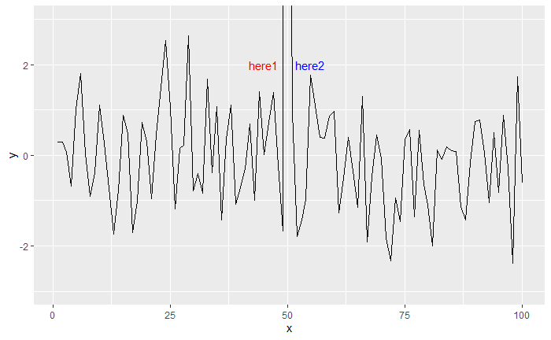